# Part II - Insights from the Prosper Loan Dataset

## by David Apine Kwenev

## Investigation Overview

The goal of this presentation is to draw our attention to some key features that possibly affect whether or not loan will be given to a borrower and the Loan Amount. The following insights will be presented and discussed:

- It was found that 31% of borrowers earn between 50000 to 75000 dollars while 28% earn between 25000 to 50000 US dollars.
- Borrowers that fall within these two Income Ranges constitute more than 50% of the entire dataset.
- 37% of the borrowers come from 5 states namely (in decreasing order of pupolarity); California, New York, Texas, Florida, and Illinois with California taking the lead with about 13% borrowers.
- 64% of the borrowers listed **Debt Consolidation** as their reason for taking the loan. Only about 5% of them mentioned **Business** as reason for the loan.
- Being a home owner as well as having a high income plays a very big role on the Loan Amount.

## Dataset Overview

The dataset contains 113,937 records of loans with 81 features for each loan.  
The data dictionary explains the features in the data set.

## Visualization1: How the Income Range of the borrowers is distributed

It was found from the analysis that 31% of borrowers earn between 50000 to 75000 dollars while 28% earn between 25000 to 50000 US dollars.  
It is also worthy of note that, borrowers that fall within these two Income Ranges constitute more than 50% of the entire sample.

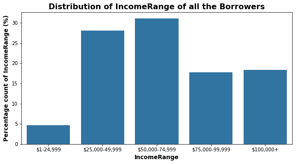

## Visualization 2: Top 5 borrowing states

- 37% of the borrowers come from 5 states namely (in decreasing order of pupolarity); California, New York, Texas, Florida, and Illinois with California taking the lead with about 13% borrowers.

The population in these states could be the reason why they have more borrowers however, no futher analysis was done taking population into account to ascertain this claim.

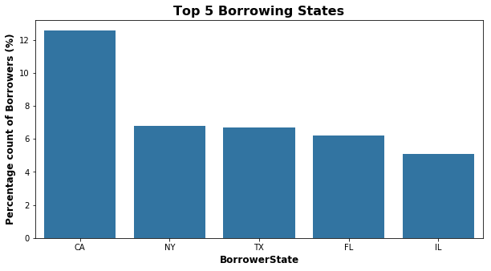

## Visualization 3: Top 5 Listing Categories of the Borrowers

- 64% of the borrowers listed **Debt Consolidation** as their reason for taking the loan.
- Only about 5% of them mentioned **Business** as the reason for the loan.

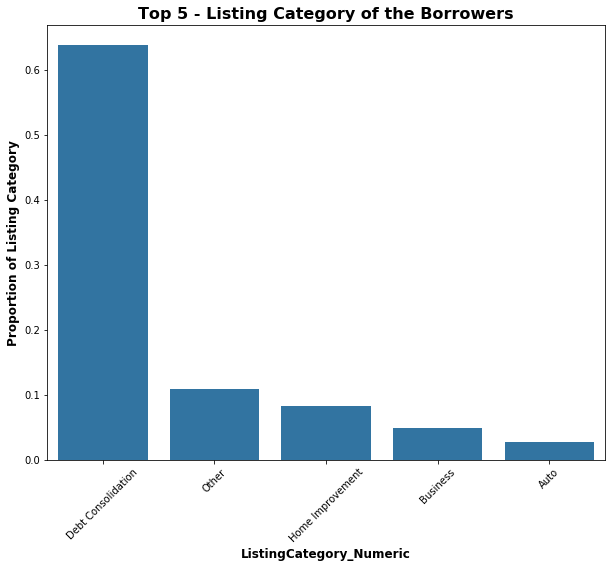

## Visualization 4:

### How Home owner status, IncomeRange of borrower and Loan Amount are related.

- Being a home owner as well as having a high income plays a very big role on the Loan Amount.
- Home owners consistently have higher Loan Amount across all Income Ranges.

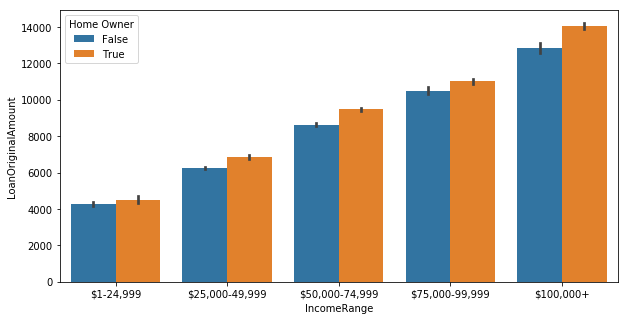